# Risk Factor Analysis

## Outcome Variable

**Outcome Variable:** wast_rec90d

## Predictor Variables

**Intervention Variable:** hhwealth_quart

**Adjustment Set:**

- arm
- sex
- W_mage
- meducyrs
- feducyrs
- W_gagebrth
- W_birthwt
- W_birthlen
- W_nchldlt5
- W_parity
- delta_W_mage
- delta_meducyrs
- delta_feducyrs
- delta_W_gagebrth
- delta_W_birthwt
- delta_W_birthlen
- delta_W_nchldlt5
- delta_W_parity

## Stratifying Variables

The analysis was stratified on these variable(s):

- agecat
- studyid
- country

## Data Summary

| agecat | studyid | country | hhwealth_quart | wast_rec90d | n_cell | n |
| --- | --- | --- | --- | --- | --- | --- |
| 0-24 months | CMC-V-BCS-2002 | INDIA | Wealth Q4 | 0 | 20 | 324 |
| 0-24 months | CMC-V-BCS-2002 | INDIA | Wealth Q4 | 1 | 49 | 324 |
| 0-24 months | CMC-V-BCS-2002 | INDIA | Wealth Q1 | 0 | 34 | 324 |
| 0-24 months | CMC-V-BCS-2002 | INDIA | Wealth Q1 | 1 | 45 | 324 |
| 0-24 months | CMC-V-BCS-2002 | INDIA | Wealth Q2 | 0 | 35 | 324 |
| 0-24 months | CMC-V-BCS-2002 | INDIA | Wealth Q2 | 1 | 64 | 324 |
| 0-24 months | CMC-V-BCS-2002 | INDIA | Wealth Q3 | 0 | 31 | 324 |
| 0-24 months | CMC-V-BCS-2002 | INDIA | Wealth Q3 | 1 | 46 | 324 |
| 0-24 months | COHORTS | GUATEMALA | Wealth Q4 | 0 | 68 | 368 |
| 0-24 months | COHORTS | GUATEMALA | Wealth Q4 | 1 | 55 | 368 |
| 0-24 months | COHORTS | GUATEMALA | Wealth Q1 | 0 | 44 | 368 |
| 0-24 months | COHORTS | GUATEMALA | Wealth Q1 | 1 | 43 | 368 |
| 0-24 months | COHORTS | GUATEMALA | Wealth Q2 | 0 | 44 | 368 |
| 0-24 months | COHORTS | GUATEMALA | Wealth Q2 | 1 | 33 | 368 |
| 0-24 months | COHORTS | GUATEMALA | Wealth Q3 | 0 | 48 | 368 |
| 0-24 months | COHORTS | GUATEMALA | Wealth Q3 | 1 | 33 | 368 |
| 0-24 months | COHORTS | PHILIPPINES | Wealth Q4 | 0 | 135 | 1689 |
| 0-24 months | COHORTS | PHILIPPINES | Wealth Q4 | 1 | 269 | 1689 |
| 0-24 months | COHORTS | PHILIPPINES | Wealth Q1 | 0 | 183 | 1689 |
| 0-24 months | COHORTS | PHILIPPINES | Wealth Q1 | 1 | 256 | 1689 |
| 0-24 months | COHORTS | PHILIPPINES | Wealth Q2 | 0 | 127 | 1689 |
| 0-24 months | COHORTS | PHILIPPINES | Wealth Q2 | 1 | 159 | 1689 |
| 0-24 months | COHORTS | PHILIPPINES | Wealth Q3 | 0 | 219 | 1689 |
| 0-24 months | COHORTS | PHILIPPINES | Wealth Q3 | 1 | 341 | 1689 |
| 0-24 months | CONTENT | PERU | Wealth Q4 | 0 | 1 | 7 |
| 0-24 months | CONTENT | PERU | Wealth Q4 | 1 | 3 | 7 |
| 0-24 months | CONTENT | PERU | Wealth Q1 | 0 | 0 | 7 |
| 0-24 months | CONTENT | PERU | Wealth Q1 | 1 | 1 | 7 |
| 0-24 months | CONTENT | PERU | Wealth Q2 | 0 | 0 | 7 |
| 0-24 months | CONTENT | PERU | Wealth Q2 | 1 | 2 | 7 |

[output cut: 402 more lines]

The following strata were considered:

- agecat: 0-24 months, studyid: CMC-V-BCS-2002, country: INDIA
- agecat: 0-24 months, studyid: COHORTS, country: GUATEMALA
- agecat: 0-24 months, studyid: COHORTS, country: PHILIPPINES
- agecat: 0-24 months, studyid: CONTENT, country: PERU
- agecat: 0-24 months, studyid: GMS-Nepal, country: NEPAL
- agecat: 0-24 months, studyid: IRC, country: INDIA
- agecat: 0-24 months, studyid: JiVitA-3, country: BANGLADESH
- agecat: 0-24 months, studyid: JiVitA-4, country: BANGLADESH
- agecat: 0-24 months, studyid: LCNI-5, country: MALAWI
- agecat: 0-24 months, studyid: MAL-ED, country: BANGLADESH
- agecat: 0-24 months, studyid: MAL-ED, country: BRAZIL
- agecat: 0-24 months, studyid: MAL-ED, country: INDIA
- agecat: 0-24 months, studyid: MAL-ED, country: NEPAL
- agecat: 0-24 months, studyid: MAL-ED, country: PERU
- agecat: 0-24 months, studyid: MAL-ED, country: SOUTH AFRICA
- agecat: 0-24 months, studyid: MAL-ED, country: TANZANIA, UNITED REPUBLIC OF
- agecat: 0-24 months, studyid: PROVIDE, country: BANGLADESH
- agecat: 0-24 months, studyid: TanzaniaChild2, country: TANZANIA, UNITED REPUBLIC OF
- agecat: 0-6 months, studyid: CMC-V-BCS-2002, country: INDIA
- agecat: 0-6 months, studyid: COHORTS, country: GUATEMALA
- agecat: 0-6 months, studyid: COHORTS, country: PHILIPPINES
- agecat: 0-6 months, studyid: CONTENT, country: PERU
- agecat: 0-6 months, studyid: GMS-Nepal, country: NEPAL
- agecat: 0-6 months, studyid: IRC, country: INDIA
- agecat: 0-6 months, studyid: JiVitA-3, country: BANGLADESH
- agecat: 0-6 months, studyid: JiVitA-4, country: BANGLADESH
- agecat: 0-6 months, studyid: LCNI-5, country: MALAWI
- agecat: 0-6 months, studyid: MAL-ED, country: BANGLADESH
- agecat: 0-6 months, studyid: MAL-ED, country: BRAZIL
- agecat: 0-6 months, studyid: MAL-ED, country: INDIA
- agecat: 0-6 months, studyid: MAL-ED, country: NEPAL
- agecat: 0-6 months, studyid: MAL-ED, country: PERU
- agecat: 0-6 months, studyid: MAL-ED, country: SOUTH AFRICA
- agecat: 0-6 months, studyid: MAL-ED, country: TANZANIA, UNITED REPUBLIC OF
- agecat: 0-6 months, studyid: PROVIDE, country: BANGLADESH
- agecat: 0-6 months, studyid: TanzaniaChild2, country: TANZANIA, UNITED REPUBLIC OF
- agecat: 6-24 months, studyid: CMC-V-BCS-2002, country: INDIA
- agecat: 6-24 months, studyid: COHORTS, country: GUATEMALA
- agecat: 6-24 months, studyid: COHORTS, country: PHILIPPINES
- agecat: 6-24 months, studyid: CONTENT, country: PERU
- agecat: 6-24 months, studyid: GMS-Nepal, country: NEPAL
- agecat: 6-24 months, studyid: IRC, country: INDIA
- agecat: 6-24 months, studyid: JiVitA-3, country: BANGLADESH
- agecat: 6-24 months, studyid: JiVitA-4, country: BANGLADESH
- agecat: 6-24 months, studyid: LCNI-5, country: MALAWI
- agecat: 6-24 months, studyid: MAL-ED, country: BANGLADESH
- agecat: 6-24 months, studyid: MAL-ED, country: BRAZIL
- agecat: 6-24 months, studyid: MAL-ED, country: INDIA
- agecat: 6-24 months, studyid: MAL-ED, country: NEPAL
- agecat: 6-24 months, studyid: MAL-ED, country: PERU
- agecat: 6-24 months, studyid: MAL-ED, country: SOUTH AFRICA
- agecat: 6-24 months, studyid: MAL-ED, country: TANZANIA, UNITED REPUBLIC OF
- agecat: 6-24 months, studyid: PROVIDE, country: BANGLADESH
- agecat: 6-24 months, studyid: TanzaniaChild2, country: TANZANIA, UNITED REPUBLIC OF

### Dropped Strata

Some strata were dropped due to rare outcomes:

- agecat: 0-24 months, studyid: CONTENT, country: PERU
- agecat: 0-24 months, studyid: LCNI-5, country: MALAWI
- agecat: 0-24 months, studyid: MAL-ED, country: BRAZIL
- agecat: 0-24 months, studyid: MAL-ED, country: NEPAL
- agecat: 0-24 months, studyid: MAL-ED, country: PERU
- agecat: 0-24 months, studyid: MAL-ED, country: SOUTH AFRICA
- agecat: 0-24 months, studyid: MAL-ED, country: TANZANIA, UNITED REPUBLIC OF
- agecat: 0-6 months, studyid: CONTENT, country: PERU
- agecat: 0-6 months, studyid: LCNI-5, country: MALAWI
- agecat: 0-6 months, studyid: MAL-ED, country: BANGLADESH
- agecat: 0-6 months, studyid: MAL-ED, country: BRAZIL
- agecat: 0-6 months, studyid: MAL-ED, country: INDIA
- agecat: 0-6 months, studyid: MAL-ED, country: NEPAL
- agecat: 0-6 months, studyid: MAL-ED, country: PERU
- agecat: 0-6 months, studyid: MAL-ED, country: SOUTH AFRICA
- agecat: 0-6 months, studyid: MAL-ED, country: TANZANIA, UNITED REPUBLIC OF
- agecat: 6-24 months, studyid: COHORTS, country: GUATEMALA
- agecat: 6-24 months, studyid: CONTENT, country: PERU
- agecat: 6-24 months, studyid: JiVitA-3, country: BANGLADESH
- agecat: 6-24 months, studyid: LCNI-5, country: MALAWI
- agecat: 6-24 months, studyid: MAL-ED, country: BANGLADESH
- agecat: 6-24 months, studyid: MAL-ED, country: BRAZIL
- agecat: 6-24 months, studyid: MAL-ED, country: NEPAL
- agecat: 6-24 months, studyid: MAL-ED, country: PERU
- agecat: 6-24 months, studyid: MAL-ED, country: SOUTH AFRICA
- agecat: 6-24 months, studyid: MAL-ED, country: TANZANIA, UNITED REPUBLIC OF

## Methods Detail

We’re interested in the causal parameters $E[Y_a]$ for all values of $a \in \mathcal{A}$. These parameters represent the mean outcome if, possibly contrary to fact, we intervened to set all units to have $A=a$. Under the randomization and positivity assumptions, these are identified by the statistical parameters $\psi_a=E_W[E_{Y|A,W}(Y|A=a,W)]$. In addition, we’re interested in the mean of $Y$, $E[Y]$ under no intervention (the observed mean). We will estimate these parameters by using SuperLearner to fit the relevant likelihood factors – $E_{Y|A,W}(Y|A=a,W)$ and $p(A=a|W)$, and then updating our likelihood fit using a joint TMLE.

For unadjusted analyses ($W=\{\}$), initial likelihoods were estimated using Lrnr_glm to estimate the simple $E(Y|A)$ and Lrnr_mean to estimate $p(A)$. For adjusted analyses, a small library containing Lrnr_glmnet, Lrnr_xgboost, and Lrnr_mean was used.

Having estimated these parameters, we will then use the delta method to estimate relative risks and attributable risks relative to a prespecified baseline level of $A$.

# Results Detail

## Results Plots

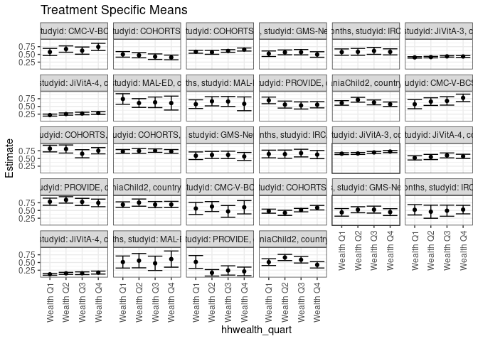

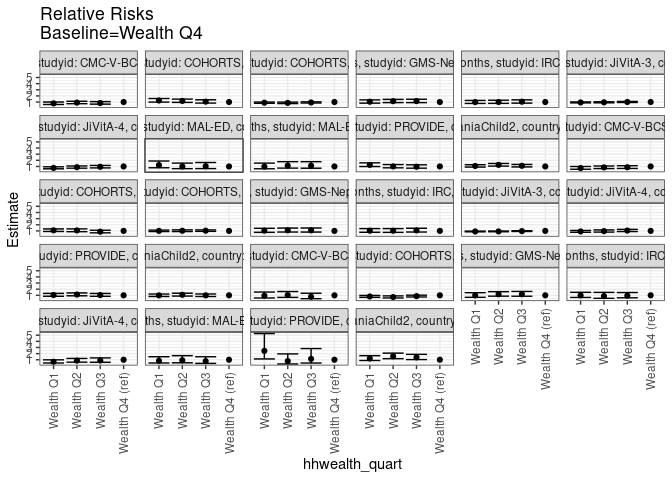

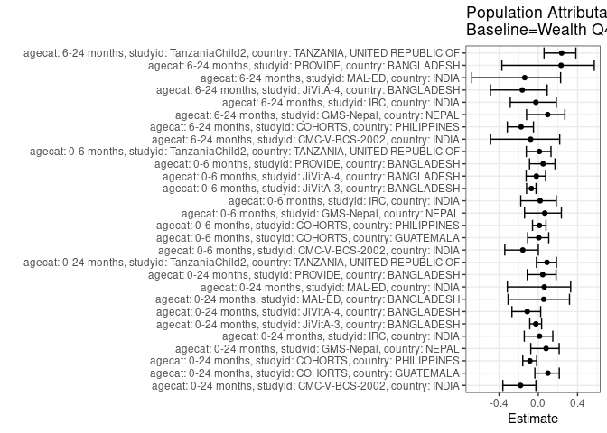

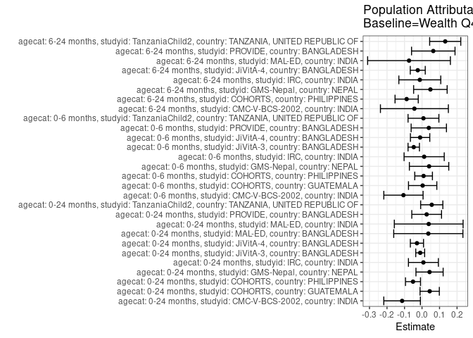

## Results Table

### Parameter: TSM

| agecat | studyid | country | intervention_level | baseline_level | estimate | ci_lower | ci_upper |
| --- | --- | --- | --- | --- | --- | --- | --- |
| 0-24 months | CMC-V-BCS-2002 | INDIA | Wealth Q4 | NA | 0.7434226 | 0.6282056 | 0.8586397 |
| 0-24 months | CMC-V-BCS-2002 | INDIA | Wealth Q1 | NA | 0.5782638 | 0.4621124 | 0.6944152 |
| 0-24 months | CMC-V-BCS-2002 | INDIA | Wealth Q2 | NA | 0.6733313 | 0.5710923 | 0.7755702 |
| 0-24 months | CMC-V-BCS-2002 | INDIA | Wealth Q3 | NA | 0.6223050 | 0.5057412 | 0.7388688 |
| 0-24 months | COHORTS | GUATEMALA | Wealth Q4 | NA | 0.4018912 | 0.3264449 | 0.4773375 |
| 0-24 months | COHORTS | GUATEMALA | Wealth Q1 | NA | 0.5010026 | 0.4109937 | 0.5910115 |
| 0-24 months | COHORTS | GUATEMALA | Wealth Q2 | NA | 0.4738809 | 0.3899858 | 0.5577759 |
| 0-24 months | COHORTS | GUATEMALA | Wealth Q3 | NA | 0.4264610 | 0.3377615 | 0.5151606 |
| 0-24 months | COHORTS | PHILIPPINES | Wealth Q4 | NA | 0.6583620 | 0.6093617 | 0.7073622 |
| 0-24 months | COHORTS | PHILIPPINES | Wealth Q1 | NA | 0.5853920 | 0.5376287 | 0.6331552 |
| 0-24 months | COHORTS | PHILIPPINES | Wealth Q2 | NA | 0.5671485 | 0.5032095 | 0.6310876 |
| 0-24 months | COHORTS | PHILIPPINES | Wealth Q3 | NA | 0.6111438 | 0.5687132 | 0.6535743 |
| 0-24 months | GMS-Nepal | NEPAL | Wealth Q4 | NA | 0.4966882 | 0.4074380 | 0.5859385 |
| 0-24 months | GMS-Nepal | NEPAL | Wealth Q1 | NA | 0.5220979 | 0.4328067 | 0.6113891 |
| 0-24 months | GMS-Nepal | NEPAL | Wealth Q2 | NA | 0.5654708 | 0.4872952 | 0.6436463 |
| 0-24 months | GMS-Nepal | NEPAL | Wealth Q3 | NA | 0.5710124 | 0.4840281 | 0.6579966 |
| 0-24 months | IRC | INDIA | Wealth Q4 | NA | 0.5819662 | 0.4835817 | 0.6803507 |
| 0-24 months | IRC | INDIA | Wealth Q1 | NA | 0.5749095 | 0.4725216 | 0.6772974 |
| 0-24 months | IRC | INDIA | Wealth Q2 | NA | 0.5835059 | 0.4734391 | 0.6935728 |
| 0-24 months | IRC | INDIA | Wealth Q3 | NA | 0.6134650 | 0.5006763 | 0.7262537 |
| 0-24 months | JiVitA-3 | BANGLADESH | Wealth Q4 | NA | 0.4328166 | 0.4051035 | 0.4605297 |
| 0-24 months | JiVitA-3 | BANGLADESH | Wealth Q1 | NA | 0.4034132 | 0.3801729 | 0.4266534 |
| 0-24 months | JiVitA-3 | BANGLADESH | Wealth Q2 | NA | 0.4125697 | 0.3881691 | 0.4369704 |
| 0-24 months | JiVitA-3 | BANGLADESH | Wealth Q3 | NA | 0.4356379 | 0.4119807 | 0.4592950 |
| 0-24 months | JiVitA-4 | BANGLADESH | Wealth Q4 | NA | 0.2870080 | 0.2440532 | 0.3299627 |
| 0-24 months | JiVitA-4 | BANGLADESH | Wealth Q1 | NA | 0.2189035 | 0.1860754 | 0.2517316 |
| 0-24 months | JiVitA-4 | BANGLADESH | Wealth Q2 | NA | 0.2529331 | 0.2165492 | 0.2893170 |
| 0-24 months | JiVitA-4 | BANGLADESH | Wealth Q3 | NA | 0.2714257 | 0.2298260 | 0.3130254 |
| 0-24 months | MAL-ED | BANGLADESH | Wealth Q4 | NA | 0.6086957 | 0.3833475 | 0.8340438 |
| 0-24 months | MAL-ED | BANGLADESH | Wealth Q1 | NA | 0.7407407 | 0.5697050 | 0.9117765 |

[output cut: 82 more lines]

### Parameter: E(Y)

| agecat | studyid | country | intervention_level | baseline_level | estimate | ci_lower | ci_upper |
| --- | --- | --- | --- | --- | --- | --- | --- |
| 0-24 months | CMC-V-BCS-2002 | INDIA | NA | NA | 0.6296296 | 0.5734927 | 0.6857665 |
| 0-24 months | COHORTS | GUATEMALA | NA | NA | 0.4456522 | 0.3930622 | 0.4982422 |
| 0-24 months | COHORTS | PHILIPPINES | NA | NA | 0.6068680 | 0.5823645 | 0.6313715 |
| 0-24 months | GMS-Nepal | NEPAL | NA | NA | 0.5396579 | 0.4973524 | 0.5819633 |
| 0-24 months | IRC | INDIA | NA | NA | 0.5898734 | 0.5376978 | 0.6420491 |
| 0-24 months | JiVitA-3 | BANGLADESH | NA | NA | 0.4223750 | 0.4112475 | 0.4335026 |
| 0-24 months | JiVitA-4 | BANGLADESH | NA | NA | 0.2580019 | 0.2386523 | 0.2773515 |
| 0-24 months | MAL-ED | BANGLADESH | NA | NA | 0.6446281 | 0.5577732 | 0.7314830 |
| 0-24 months | MAL-ED | INDIA | NA | NA | 0.6228571 | 0.5433246 | 0.7023896 |
| 0-24 months | PROVIDE | BANGLADESH | NA | NA | 0.5811688 | 0.5245443 | 0.6377934 |
| 0-24 months | TanzaniaChild2 | TANZANIA, UNITED REPUBLIC OF | NA | NA | 0.6258790 | 0.5881498 | 0.6636083 |
| 0-6 months | CMC-V-BCS-2002 | INDIA | NA | NA | 0.6716418 | 0.6057305 | 0.7375531 |
| 0-6 months | COHORTS | GUATEMALA | NA | NA | 0.7536232 | 0.6949302 | 0.8123162 |
| 0-6 months | COHORTS | PHILIPPINES | NA | NA | 0.7367021 | 0.7051294 | 0.7682749 |
| 0-6 months | GMS-Nepal | NEPAL | NA | NA | 0.6045627 | 0.5449300 | 0.6641955 |
| 0-6 months | IRC | INDIA | NA | NA | 0.6375000 | 0.5751450 | 0.6998550 |
| 0-6 months | JiVitA-3 | BANGLADESH | NA | NA | 0.6752643 | 0.6619190 | 0.6886095 |
| 0-6 months | JiVitA-4 | BANGLADESH | NA | NA | 0.5583942 | 0.5167799 | 0.6000084 |
| 0-6 months | PROVIDE | BANGLADESH | NA | NA | 0.7837838 | 0.7252863 | 0.8422812 |
| 0-6 months | TanzaniaChild2 | TANZANIA, UNITED REPUBLIC OF | NA | NA | 0.7020649 | 0.6526590 | 0.7514708 |
| 6-24 months | CMC-V-BCS-2002 | INDIA | NA | NA | 0.5609756 | 0.4682842 | 0.6536670 |
| 6-24 months | COHORTS | PHILIPPINES | NA | NA | 0.5026681 | 0.4688378 | 0.5364984 |
| 6-24 months | GMS-Nepal | NEPAL | NA | NA | 0.4947368 | 0.4401559 | 0.5493178 |
| 6-24 months | IRC | INDIA | NA | NA | 0.5161290 | 0.4322562 | 0.6000019 |
| 6-24 months | JiVitA-4 | BANGLADESH | NA | NA | 0.1492734 | 0.1316631 | 0.1668838 |
| 6-24 months | MAL-ED | INDIA | NA | NA | 0.5368421 | 0.4223932 | 0.6512910 |
| 6-24 months | PROVIDE | BANGLADESH | NA | NA | 0.2764228 | 0.1950773 | 0.3577682 |
| 6-24 months | TanzaniaChild2 | TANZANIA, UNITED REPUBLIC OF | NA | NA | 0.5564516 | 0.5041613 | 0.6087419 |

### Parameter: RR

| agecat | studyid | country | intervention_level | baseline_level | estimate | ci_lower | ci_upper |
| --- | --- | --- | --- | --- | --- | --- | --- |
| 0-24 months | CMC-V-BCS-2002 | INDIA | Wealth Q4 | Wealth Q4 | 1.0000000 | 1.0000000 | 1.0000000 |
| 0-24 months | CMC-V-BCS-2002 | INDIA | Wealth Q1 | Wealth Q4 | 0.7778399 | 0.6030785 | 1.0032441 |
| 0-24 months | CMC-V-BCS-2002 | INDIA | Wealth Q2 | Wealth Q4 | 0.9057180 | 0.7296343 | 1.1242962 |
| 0-24 months | CMC-V-BCS-2002 | INDIA | Wealth Q3 | Wealth Q4 | 0.8370811 | 0.6560367 | 1.0680876 |
| 0-24 months | COHORTS | GUATEMALA | Wealth Q4 | Wealth Q4 | 1.0000000 | 1.0000000 | 1.0000000 |
| 0-24 months | COHORTS | GUATEMALA | Wealth Q1 | Wealth Q4 | 1.2466125 | 0.9846307 | 1.5783001 |
| 0-24 months | COHORTS | GUATEMALA | Wealth Q2 | Wealth Q4 | 1.1791272 | 0.9393920 | 1.4800433 |
| 0-24 months | COHORTS | GUATEMALA | Wealth Q3 | Wealth Q4 | 1.0611354 | 0.8257881 | 1.3635561 |
| 0-24 months | COHORTS | PHILIPPINES | Wealth Q4 | Wealth Q4 | 1.0000000 | 1.0000000 | 1.0000000 |
| 0-24 months | COHORTS | PHILIPPINES | Wealth Q1 | Wealth Q4 | 0.8891643 | 0.7963223 | 0.9928306 |
| 0-24 months | COHORTS | PHILIPPINES | Wealth Q2 | Wealth Q4 | 0.8614540 | 0.7526260 | 0.9860182 |
| 0-24 months | COHORTS | PHILIPPINES | Wealth Q3 | Wealth Q4 | 0.9282793 | 0.8386081 | 1.0275389 |
| 0-24 months | GMS-Nepal | NEPAL | Wealth Q4 | Wealth Q4 | 1.0000000 | 1.0000000 | 1.0000000 |
| 0-24 months | GMS-Nepal | NEPAL | Wealth Q1 | Wealth Q4 | 1.0511582 | 0.8202731 | 1.3470312 |
| 0-24 months | GMS-Nepal | NEPAL | Wealth Q2 | Wealth Q4 | 1.1384823 | 0.9078232 | 1.4277470 |
| 0-24 months | GMS-Nepal | NEPAL | Wealth Q3 | Wealth Q4 | 1.1496394 | 0.9082695 | 1.4551526 |
| 0-24 months | IRC | INDIA | Wealth Q4 | Wealth Q4 | 1.0000000 | 1.0000000 | 1.0000000 |
| 0-24 months | IRC | INDIA | Wealth Q1 | Wealth Q4 | 0.9878743 | 0.7727086 | 1.2629543 |
| 0-24 months | IRC | INDIA | Wealth Q2 | Wealth Q4 | 1.0026457 | 0.7782064 | 1.2918145 |
| 0-24 months | IRC | INDIA | Wealth Q3 | Wealth Q4 | 1.0541247 | 0.8209429 | 1.3535399 |
| 0-24 months | JiVitA-3 | BANGLADESH | Wealth Q4 | Wealth Q4 | 1.0000000 | 1.0000000 | 1.0000000 |
| 0-24 months | JiVitA-3 | BANGLADESH | Wealth Q1 | Wealth Q4 | 0.9320648 | 0.8563972 | 1.0144181 |
| 0-24 months | JiVitA-3 | BANGLADESH | Wealth Q2 | Wealth Q4 | 0.9532206 | 0.8747478 | 1.0387331 |
| 0-24 months | JiVitA-3 | BANGLADESH | Wealth Q3 | Wealth Q4 | 1.0065183 | 0.9267670 | 1.0931325 |
| 0-24 months | JiVitA-4 | BANGLADESH | Wealth Q4 | Wealth Q4 | 1.0000000 | 1.0000000 | 1.0000000 |
| 0-24 months | JiVitA-4 | BANGLADESH | Wealth Q1 | Wealth Q4 | 0.7627089 | 0.6195744 | 0.9389104 |
| 0-24 months | JiVitA-4 | BANGLADESH | Wealth Q2 | Wealth Q4 | 0.8812754 | 0.7191701 | 1.0799203 |
| 0-24 months | JiVitA-4 | BANGLADESH | Wealth Q3 | Wealth Q4 | 0.9457079 | 0.7665670 | 1.1667126 |
| 0-24 months | MAL-ED | BANGLADESH | Wealth Q4 | Wealth Q4 | 1.0000000 | 1.0000000 | 1.0000000 |
| 0-24 months | MAL-ED | BANGLADESH | Wealth Q1 | Wealth Q4 | 1.2169312 | 0.7866441 | 1.8825814 |

[output cut: 82 more lines]

### Parameter: PAR

| agecat | studyid | country | intervention_level | baseline_level | estimate | ci_lower | ci_upper |
| --- | --- | --- | --- | --- | --- | --- | --- |
| 0-24 months | CMC-V-BCS-2002 | INDIA | Wealth Q4 | NA | -0.1137930 | -0.2182461 | -0.0093399 |
| 0-24 months | COHORTS | GUATEMALA | Wealth Q4 | NA | 0.0437609 | -0.0112930 | 0.0988149 |
| 0-24 months | COHORTS | PHILIPPINES | Wealth Q4 | NA | -0.0514940 | -0.0943655 | -0.0086225 |
| 0-24 months | GMS-Nepal | NEPAL | Wealth Q4 | NA | 0.0429696 | -0.0346622 | 0.1206014 |
| 0-24 months | IRC | INDIA | Wealth Q4 | NA | 0.0079072 | -0.0775629 | 0.0933772 |
| 0-24 months | JiVitA-3 | BANGLADESH | Wealth Q4 | NA | -0.0104416 | -0.0358897 | 0.0150065 |
| 0-24 months | JiVitA-4 | BANGLADESH | Wealth Q4 | NA | -0.0290060 | -0.0666746 | 0.0086625 |
| 0-24 months | MAL-ED | BANGLADESH | Wealth Q4 | NA | 0.0359324 | -0.1615889 | 0.2334538 |
| 0-24 months | MAL-ED | INDIA | Wealth Q4 | NA | 0.0381497 | -0.1581698 | 0.2344693 |
| 0-24 months | PROVIDE | BANGLADESH | Wealth Q4 | NA | 0.0264565 | -0.0584795 | 0.1113925 |
| 0-24 months | TanzaniaChild2 | TANZANIA, UNITED REPUBLIC OF | Wealth Q4 | NA | 0.0555210 | -0.0079389 | 0.1189810 |
| 0-6 months | CMC-V-BCS-2002 | INDIA | Wealth Q4 | NA | -0.1060159 | -0.2181458 | 0.0061140 |
| 0-6 months | COHORTS | GUATEMALA | Wealth Q4 | NA | 0.0036232 | -0.0772108 | 0.0844571 |
| 0-6 months | COHORTS | PHILIPPINES | Wealth Q4 | NA | 0.0089954 | -0.0414512 | 0.0594420 |
| 0-6 months | GMS-Nepal | NEPAL | Wealth Q4 | NA | 0.0402416 | -0.0721612 | 0.1526445 |
| 0-6 months | IRC | INDIA | Wealth Q4 | NA | 0.0121753 | -0.1024616 | 0.1268122 |
| 0-6 months | JiVitA-3 | BANGLADESH | Wealth Q4 | NA | -0.0473356 | -0.0799182 | -0.0147530 |
| 0-6 months | JiVitA-4 | BANGLADESH | Wealth Q4 | NA | -0.0110134 | -0.0662153 | 0.0441885 |
| 0-6 months | PROVIDE | BANGLADESH | Wealth Q4 | NA | 0.0386857 | -0.0621324 | 0.1395039 |
| 0-6 months | TanzaniaChild2 | TANZANIA, UNITED REPUBLIC OF | Wealth Q4 | NA | 0.0081452 | -0.0798742 | 0.0961647 |
| 6-24 months | CMC-V-BCS-2002 | INDIA | Wealth Q4 | NA | -0.0435201 | -0.2374763 | 0.1504361 |
| 6-24 months | COHORTS | PHILIPPINES | Wealth Q4 | NA | -0.0877971 | -0.1540771 | -0.0215171 |
| 6-24 months | GMS-Nepal | NEPAL | Wealth Q4 | NA | 0.0477487 | -0.0479730 | 0.1434703 |
| 6-24 months | IRC | INDIA | Wealth Q4 | NA | -0.0126203 | -0.1323764 | 0.1071358 |
| 6-24 months | JiVitA-4 | BANGLADESH | Wealth Q4 | NA | -0.0243331 | -0.0671243 | 0.0184582 |
| 6-24 months | MAL-ED | INDIA | Wealth Q4 | NA | -0.0742690 | -0.3105292 | 0.1619912 |
| 6-24 months | PROVIDE | BANGLADESH | Wealth Q4 | NA | 0.0643016 | -0.0598472 | 0.1884503 |
| 6-24 months | TanzaniaChild2 | TANZANIA, UNITED REPUBLIC OF | Wealth Q4 | NA | 0.1323848 | 0.0435290 | 0.2212406 |

### Parameter: PAF

| agecat | studyid | country | intervention_level | baseline_level | estimate | ci_lower | ci_upper |
| --- | --- | --- | --- | --- | --- | --- | --- |
| 0-24 months | CMC-V-BCS-2002 | INDIA | Wealth Q4 | NA | -0.1807301 | -0.3609807 | -0.0243521 |
| 0-24 months | COHORTS | GUATEMALA | Wealth Q4 | NA | 0.0981953 | -0.0345847 | 0.2139341 |
| 0-24 months | COHORTS | PHILIPPINES | Wealth Q4 | NA | -0.0848521 | -0.1580004 | -0.0163244 |
| 0-24 months | GMS-Nepal | NEPAL | Wealth Q4 | NA | 0.0796238 | -0.0764051 | 0.2130357 |
| 0-24 months | IRC | INDIA | Wealth Q4 | NA | 0.0134049 | -0.1426233 | 0.1481270 |
| 0-24 months | JiVitA-3 | BANGLADESH | Wealth Q4 | NA | -0.0247211 | -0.0867855 | 0.0337988 |
| 0-24 months | JiVitA-4 | BANGLADESH | Wealth Q4 | NA | -0.1124257 | -0.2683773 | 0.0243511 |
| 0-24 months | MAL-ED | BANGLADESH | Wealth Q4 | NA | 0.0557414 | -0.3076334 | 0.3181389 |
| 0-24 months | MAL-ED | INDIA | Wealth Q4 | NA | 0.0612496 | -0.3151739 | 0.3299347 |
| 0-24 months | PROVIDE | BANGLADESH | Wealth Q4 | NA | 0.0455229 | -0.1124245 | 0.1810441 |
| 0-24 months | TanzaniaChild2 | TANZANIA, UNITED REPUBLIC OF | Wealth Q4 | NA | 0.0887089 | -0.0186318 | 0.1847383 |
| 0-6 months | CMC-V-BCS-2002 | INDIA | Wealth Q4 | NA | -0.1578459 | -0.3410419 | 0.0003242 |
| 0-6 months | COHORTS | GUATEMALA | Wealth Q4 | NA | 0.0048077 | -0.1084546 | 0.1064968 |
| 0-6 months | COHORTS | PHILIPPINES | Wealth Q4 | NA | 0.0122103 | -0.0587257 | 0.0783936 |
| 0-6 months | GMS-Nepal | NEPAL | Wealth Q4 | NA | 0.0665632 | -0.1395801 | 0.2354165 |
| 0-6 months | IRC | INDIA | Wealth Q4 | NA | 0.0190986 | -0.1783427 | 0.1834568 |
| 0-6 months | JiVitA-3 | BANGLADESH | Wealth Q4 | NA | -0.0700994 | -0.1195495 | -0.0228335 |
| 0-6 months | JiVitA-4 | BANGLADESH | Wealth Q4 | NA | -0.0197234 | -0.1236459 | 0.0745876 |
| 0-6 months | PROVIDE | BANGLADESH | Wealth Q4 | NA | 0.0493577 | -0.0889559 | 0.1701034 |
| 0-6 months | TanzaniaChild2 | TANZANIA, UNITED REPUBLIC OF | Wealth Q4 | NA | 0.0116018 | -0.1220928 | 0.1293670 |
| 6-24 months | CMC-V-BCS-2002 | INDIA | Wealth Q4 | NA | -0.0775793 | -0.4854936 | 0.2183224 |
| 6-24 months | COHORTS | PHILIPPINES | Wealth Q4 | NA | -0.1746622 | -0.3152826 | -0.0490759 |
| 6-24 months | GMS-Nepal | NEPAL | Wealth Q4 | NA | 0.0965132 | -0.1196518 | 0.2709445 |
| 6-24 months | IRC | INDIA | Wealth Q4 | NA | -0.0244519 | -0.2854339 | 0.1835429 |
| 6-24 months | JiVitA-4 | BANGLADESH | Wealth Q4 | NA | -0.1630101 | -0.4870991 | 0.0904490 |
| 6-24 months | MAL-ED | INDIA | Wealth Q4 | NA | -0.1383442 | -0.6772300 | 0.2274002 |
| 6-24 months | PROVIDE | BANGLADESH | Wealth Q4 | NA | 0.2326203 | -0.3708498 | 0.5704332 |
| 6-24 months | TanzaniaChild2 | TANZANIA, UNITED REPUBLIC OF | Wealth Q4 | NA | 0.2379090 | 0.0588324 | 0.3829125 |